# Aortic valve analysis

Steve Simon

May 25, 2017

```r
av1 <- read.csv("av1_2017_05_29.csv", as.is=TRUE)
av3 <- read.csv("av3_2017_05_29.csv", as.is=TRUE)
av4 <- read.csv("av4_2017_05_29.csv", as.is=TRUE)

print(names(av1)[1])
```

```
## [1] "ï..PATIENTID"
```

```r
names(av1)[1] <- "id"
print(names(av3)[1])
```

```
## [1] "ï..PATIENTID"
```

```r
names(av3)[1] <- "id"
print(names(av4)[1])
```

```
## [1] "ï..PATIENTID"
```

```r
names(av4)[1] <- "id"

names(av1) %<>% tolower
names(av3) %<>% tolower
names(av4) %<>% tolower

names(av1) %<>% gsub("\\.", "_", .)
names(av3) %<>% gsub("\\.", "_", .)
names(av4) %<>% gsub("\\.", "_", .)

names(av1) %<>% gsub("_+",  "_", .)
names(av3) %<>% gsub("_+",  "_", .)
names(av4) %<>% gsub("_+",  "_", .)

names(av1) %<>% gsub("_$",  "",  .)
names(av3) %<>% gsub("_$",  "",  .)
names(av4) %<>% gsub("_$",  "",  .)
```

AORTIC

1. Arithmetic data for columns where possible – mean, median, SD, range
2. What is the long-term survival of children with AVR?
3. Head to head comparison of Ross versus Bio prosthesis versus Mechanical prosthesis looking at survival within the 3 groups ==> ross_bio_mech and relation to following
- Age at 1st AVR ==> date_of_valve_replacement MINUS birthdate
- Weight at 1st AVR ==> weight_at_surgery_kg
- Valve type at 1st AVR ==> mechanical_valve_used_y_n AND valve_make
- Valve size at 1st AVR ==> valve_size_mm
- Underlying disease ==> underlying_disease_ex_cavc_etc
- Underlying hemodynamic mechanism – AR versus AS versus both ==> underlying_lesion_regurgitation_or_stenosis
- Perfusion time ==> cpb_time_minutes
- Concomitant prosthetic MVR ==> additional_valve_replaced_mitral_pulm_tri
- Initial Hospital length of stay ==> discharge_date MINUS date_of_valve_replacement
- Era effect - < 1990 versus 1990s and up to 2003 ==> date_of_valve_replacement
- Geography – State ==> state
- Institution
4. Causes of death – Big piles only
5. Early deaths (PCCC) versus late deaths (NDI) – compare profiles
6. Interactions
7. Confounders – collinearity
8. Kaplan Meir – Ross versus Bio versus Mechanical AVR
9. Competing risk – will think thru this some more
10. Redo stuff – we may not have time for this before abstract deadline

```r
j1 <- which(grepl("^x",names(av1)))
print(names(av1)[j1])
```

```
##  [1] "x2nd_redo_y_n" "x"             "x_1"           "x_2"
##  [5] "x_3"           "x_4"           "x_5"           "x_6"
##  [9] "x_7"           "x_8"           "x_9"           "x_10"
## [13] "x_11"          "x_12"          "x_13"          "x_14"
## [17] "x_15"          "x_16"          "x_17"          "x_18"
## [21] "x_19"          "x_20"          "x_21"          "x_22"
## [25] "x_23"          "x_24"          "x_25"          "x_26"
## [29] "x_27"          "x_28"          "x_29"          "x_30"
## [33] "x_31"          "x_32"          "x_33"          "x_34"
## [37] "x_35"          "x_36"          "x_37"          "x_38"
## [41] "x_39"          "x_40"          "x_41"          "x_42"
## [45] "x_43"          "x_44"          "x_45"          "x_46"
## [49] "x_47"          "x_48"          "x_49"          "x_50"
## [53] "x_51"          "x_52"          "x_53"          "x_54"
## [57] "x_55"          "x_56"          "x_57"          "x_58"
## [61] "x_59"          "x_60"          "x_61"          "x_62"
## [65] "x_63"          "x_64"          "x_65"          "x_66"
## [69] "x_67"
```

```r
j1 <- j1[-1]
j3 <- which(grepl("^x",names(av3)))
print(j3)
```

```
## integer(0)
```

```r
j4 <- which(grepl("^x",names(av4)))
print(names(av4)[j4])
```

```
## [1] "x"   "x_1" "x_2" "x_3" "x_4"
```

```r
for (j in names(av1)[j1]) {
  x <- av1[, j]
  n <- length(x)
  is_empty <- is.na(x) | grepl("^[[:space:]]+$", x)
  if (sum(is_empty)==n) {next}
  cat("\n\n")
  cat(j)
  cat("\n")
  print(table(x[!is_empty]))
}

i1 <- which(is.na(av1$id))
print(i1)
```

```
## integer(0)
```

```r
i3 <- which(is.na(av3$id))
print(i3)
```

```
##  [1] 296 297 298 299 300 301 302 303 304 305 306 307 308 309 310 311 312
## [18] 313 314 315 316 317
```

```r
i4 <- which(is.na(av4$id))
print(i4)
```

```
## integer(0)
```

```r
for (j in names(av3)) {
  x <- av3[i3, j]
  n <- length(x)
  is_empty <- is.na(x) | x=="" | grepl("^[[:space:]]+$", x)
  if (sum(is_empty)==n) {next}
  cat("\n\n")
  cat(j)
  cat(": ")
  cat(i3[!is_empty])
  print(table(x[!is_empty]))
}
```

```
##
##
## ea_desc_2: 296
## complex congenital heart disease
##                                 1
##
##
## ea_desc_3: 296
## shock liver with extensive centrilobular necrosis
##                                                 1
```

```r
av1 <- av1[, -j1]

av3 <- av3[-i3, ]

str(av1)
```

```
## 'data.frame':    1198 obs. of  67 variables:
##  $ id                                           : num  2.89e+10 2.67e+10 2.69e+10 2.70e+10 2.81e+10 ...
##  $ birthdate                                    : chr  "1/23/1989" "10/12/1967" "7/21/1969" "6/23/1970" ...
##  $ race                                         : chr  "" "White" "Unknown" "" ...
##  $ ethnicity                                    : chr  "Unknown" "NotHispanic" "Unknown" "" ...
##  $ first_admit_date                             : chr  "8/3/1998" "6/8/1982" "1/20/1986" "10/14/1987" ...
##  $ state                                        : chr  "TX" "MN" "MO" "IL" ...
##  $ sex                                          : chr  "M" "M" "M" "M" ...
##  $ pccc_death                                   : chr  "NO" "NO" "NO" "NO" ...
##  $ region                                       : chr  "US" "US" "US" "US" ...
##  $ ndi_chd_yn                                   : chr  "YES" "YES" "YES" "YES" ...
##  $ ndi_no_first_name                            : chr  "NO" "NO" "NO" "NO" ...
##  $ ndi_submitted_yn                             : chr  "YES" "YES" "YES" "YES" ...
##  $ underlying_disease_ex_cavc_etc               : chr  "shone complex, CoA" "999" "999" "999" ...
##  $ mechanical_valve_used_y_n                    : chr  "888" "999" "999" "999" ...
```

[output cut: 53 more lines]

```r
head(av1)
```

```
##            id  birthdate    race   ethnicity first_admit_date state sex
## 1 28901230007  1/23/1989             Unknown         8/3/1998    TX   M
## 2 26710120000 10/12/1967   White NotHispanic         6/8/1982    MN   M
## 3 26907210000  7/21/1969 Unknown     Unknown        1/20/1986    MO   M
## 4 27006230000  6/23/1970                           10/14/1987    IL   M
## 5 28104030004   4/3/1981                           12/19/1997    NE   F
## 6 28206300002  6/30/1982                            8/13/1997    LA   M
##   pccc_death region ndi_chd_yn ndi_no_first_name ndi_submitted_yn
## 1         NO     US        YES                NO              YES
## 2         NO     US        YES                NO              YES
## 3         NO     US        YES                NO              YES
## 4         NO     US        YES                NO              YES
## 5         NO     US        YES                NO              YES
## 6         NO     US        YES                NO              YES
##   underlying_disease_ex_cavc_etc mechanical_valve_used_y_n
```

[output cut: 125 more lines]

```r
tail(av1)
```

```
##               id  birthdate race   ethnicity first_admit_date state sex
## 1193 29304060000   4/6/1993                          4/8/1993    FL   M
## 1194 29207220008  7/22/1992                          7/2/1998    OR   M
## 1195 27704020000   4/2/1977      NotHispanic       11/23/1986    AR   F
## 1196 27604200000  4/20/1976                         6/18/1992    KY   M
## 1197 28409170005  9/17/1984                         7/24/1993    AZ   M
## 1198 28510250012 10/25/1985                          9/9/2002    MD   M
##      pccc_death region ndi_chd_yn ndi_no_first_name ndi_submitted_yn
## 1193         NO     US        YES                NO              YES
## 1194         NO     US        YES                NO              YES
## 1195         NO     US        YES                NO              YES
## 1196         NO     US        YES                NO              YES
## 1197         NO     US        YES                NO              YES
## 1198         NO     US        YES                NO              YES
##       underlying_disease_ex_cavc_etc mechanical_valve_used_y_n
```

[output cut: 132 more lines]

```r
str(av3)
```

```
## 'data.frame':    295 obs. of  86 variables:
##  $ id                     : num  2.20e+10 2.21e+10 2.22e+10 2.29e+10 2.29e+10 ...
##  $ date_of_death          : chr  "08-29-1994" "03-22-1995" "09-02-1998" "05-21-2008" ...
##  $ state_of_death         : chr  "PENNSYLVANIA" "MINNESOTA" "MINNESOTA" "MINNESOTA" ...
##  $ cardiac_non_cardiac_y_n: chr  "N" "Y" "N" "N" ...
##  $ cause_of_death         : chr  "1539" "8781" "486" "C859" ...
##  $ cause_of_death_desc    : chr  "Malignant neoplasm of colon,Colon, unspecified" "Surgical operation and other surgical procedures as the cause of abnormal reaction of patient, or of later complication, withou"| __truncated__ "Pneumonia, organism unspecified" "Non-Hodgkin's lymphoma, unspecified…
##  $ ea_1                   : chr  "1157220" "1179910" "1179070" "11A419" ...
##  $ ea_desc_1              : chr  "Liver abscess and sequelae of chronic liver disease,Hepatic coma" "Other ill-defined and unknown causes of morbidity and mortality,Respiratory failure" "Nonspecific findings on examination of blood,Bacteraemia, unspecified" "Septicaemia, unspecified" ...
##  $ ea_2                   : chr  "2119770" "1248210" "21486 0" "21J189" ...
##  $ ea_desc_2              : chr  "Secondary malignant neoplasm of respiratory and digestive systems,Liver" "Other bacterial pneumonia,Pneumonia due to Pseudomonas" "Pneumonia, organism unspecified" "Pneumonia, unspecified" ...
##  $ ea_3                   : chr  "3115390" "2199661" "6142490" "41C80" ...
##  $ ea_desc_3              : chr  "Malignant neoplasm of colon,Colon, unspecified" "" "Other diseases of endocardium,Endocarditis, valve unspecified" "Malignant neoplasm without specification of site" ...
##  $ ea_4                   : chr  "6119520" "2287810" "6225000" "42C859" ...
##  $ ea_desc_4              : chr  "Malignant neoplasm of other and ill-defined sites,Abdomen" "Surgical operation and other surgical procedures as the cause of abnormal reaction of patient, or of later complication, withou"| __truncated__ "Diabetes mellitus,Diabetes mellitus without mention of com…
```

[output cut: 72 more lines]

```r
head(av3)
```

```
##            id date_of_death state_of_death cardiac_non_cardiac_y_n
## 1 22006190000    08-29-1994   PENNSYLVANIA                       N
## 2 22107130000    03-22-1995      MINNESOTA                       Y
## 3 22206220000    09-02-1998      MINNESOTA                       N
## 4 22906030000    05-21-2008      MINNESOTA                       N
## 5 22907040000    05-14-2006   PENNSYLVANIA                       Y
## 6 23306080000    04-28-1997           OHIO                       Y
##   cause_of_death
## 1           1539
## 2           8781
## 3            486
## 4           C859
## 5           I251
## 6            410
##                                                                                                                                                                                                                               cause_of_death_desc
## 1                                                                                                                                                                                                  Malignant neoplasm of colon,Colon, unspecified
## 2 Surgical operation and other surgical procedures as the cause of abnormal reaction of patient, or of later complication, without mention of misadventure at the time of operation,Surgical operation with implant of artificial internal device
## 3                                                                                                                                                                                                                 Pneumonia, organism unspecified
## 4                                                                                                                                                                                                        Non-Hodgkin's lymphoma, unspecified type
## 5                                                                                                                                                                                                                   Atherosclerotic heart disease
## 6                                                                                                                                                                                                                     Acute myocardial infarction
##      ea_1
## 1 1157220
## 2 1179910
## 3 1179070
## 4  11A419
## 5  11I500
## 6 11410 0
##                                                                             ea_desc_1
## 1                    Liver abscess and sequelae of chronic liver disease,Hepatic coma
## 2 Other ill-defined and unknown causes of morbidity and mortality,Respiratory failure
## 3               Nonspecific findings on examination of blood,Bacteraemia, unspecified
## 4                                                            Septicaemia, unspecified
## 5                                                            Congestive heart failure
## 6                                                         Acute myocardial infarction
##      ea_2
## 1 2119770
## 2 1248210
## 3 21486 0
## 4  21J189
```

[output cut: 169 more lines]

```
## 6         NA    NA         NA    NA         NA    NA         NA    NA
##   ra_desc_16 ra_17 ra_desc_17 ra_18 ra_desc_18 ra_19 ra_desc_19 ra_20
## 1         NA    NA         NA    NA         NA    NA         NA    NA
## 2         NA    NA         NA    NA         NA    NA         NA    NA
## 3         NA    NA         NA    NA         NA    NA         NA    NA
## 4         NA    NA         NA    NA         NA    NA         NA    NA
## 5         NA    NA         NA    NA         NA    NA         NA    NA
## 6         NA    NA         NA    NA         NA    NA         NA    NA
##   ra_desc_20
## 1         NA
## 2         NA
## 3         NA
## 4         NA
## 5         NA
## 6         NA
```

```r
tail(av3)
```

```
##              id date_of_death state_of_death cardiac_non_cardiac_y_n
## 290 30112060004    01-04-2002          TEXAS                       Y
## 291 30201130005    11-20-2007   MASSACHUSETT                       Y
## 292 30203030000    12-06-2006      MINNESOTA                       Y
## 293 30207170001    12-02-2002      LOUISIANA                       Y
## 294 30208190003    12-08-2011     WASHINGTON                       N
## 295 30210220003    11-08-2002           IOWA                       Y
##     cause_of_death
## 290           Q228
## 291           I219
## 292           Q249
## 293           I461
## 294           V030
## 295           Q230
##                                                                     cause_of_death_desc
## 290                                   Other congenital malformations of tricuspid valve
## 291                                            Acute myocardial infarction, unspecified
## 292                                       Congenital malformation of heart, unspecified
## 293                                                  Sudden cardiac death, so described
## 294 Pedestrian injured in collision with car, pick-up truck or van, nontraffic accident
## 295                                                 Congenital stenosis of aortic valve
##       ea_1
## 290 11J969
## 291 11I219
## 292 11I978
## 293 11I461
## 294 11S099
## 295 11Q230
##                                                                          ea_desc_1
## 290                                               Respiratory failure, unspecified
## 291                                       Acute myocardial infarction, unspecified
## 292 Other postprocedural disorders of circulatory system, not elsewhere classified
## 293                                             Sudden cardiac death, so described
## 294                                                     Unspecified injury of head
## 295                                            Congenital stenosis of aortic valve
##       ea_2
## 290 12J189
## 291 21I514
## 292 61Q249
## 293
```

[output cut: 99 more lines]

```
## 295                   NA         NA    NA         NA    NA         NA
##     ra_13 ra_desc_13 ra_14 ra_desc_14 ra_15 ra_desc_15 ra_16 ra_desc_16
## 290    NA         NA    NA         NA    NA         NA    NA         NA
## 291    NA         NA    NA         NA    NA         NA    NA         NA
## 292    NA         NA    NA         NA    NA         NA    NA         NA
## 293    NA         NA    NA         NA    NA         NA    NA         NA
## 294    NA         NA    NA         NA    NA         NA    NA         NA
## 295    NA         NA    NA         NA    NA         NA    NA         NA
##     ra_17 ra_desc_17 ra_18 ra_desc_18 ra_19 ra_desc_19 ra_20 ra_desc_20
## 290    NA         NA    NA         NA    NA         NA    NA         NA
## 291    NA         NA    NA         NA    NA         NA    NA         NA
## 292    NA         NA    NA         NA    NA         NA    NA         NA
## 293    NA         NA    NA         NA    NA         NA    NA         NA
## 294    NA         NA    NA         NA    NA         NA    NA         NA
## 295    NA         NA    NA         NA    NA         NA    NA         NA
```

```r
str(av4)
```

```
## 'data.frame':    26 obs. of  12 variables:
##  $ id                     : num  2.66e+10 2.71e+10 2.74e+10 2.80e+10 2.84e+10 ...
##  $ date_of_death          : chr  "7/6/1983" "9/6/1984" "3/17/1989" "2/7/1994" ...
##  $ cardiac_non_cardiac_y_n: chr  "N " "Y" "Y" "Y" ...
##  $ x                      : logi  NA NA NA NA NA NA ...
##  $ cause_of_death_desc    : chr  "acute diffuse hypoxic encephalopathy with tonsilar herniation" "Congestive heart failure" "cardiopulmonary arrest" "massive mediastinal hemorrhage" ...
##  $ x_1                    : logi  NA NA NA NA NA NA ...
##  $ ea_desc_1              : chr  "acute  hemorrhagic bronchopneumonia" "" "" "" ...
##  $ x_2                    : logi  NA NA NA NA NA NA ...
##  $ ea_desc_2              : chr  "complex congenital heart disease " "" "" "" ...
##  $ x_3                    : logi  NA NA NA NA NA NA ...
##  $ ea_desc_3              : chr  "shock liver with extensive centrilobular necrosis" "" "" "" ...
##  $ x_4                    : logi  NA NA NA NA NA NA ...
```

```r
head(av4)
```

```
##            id date_of_death cardiac_non_cardiac_y_n  x
## 1 26601040001      7/6/1983                      N  NA
## 2 27106250002      9/6/1984                       Y NA
## 3 27409010001     3/17/1989                       Y NA
## 4 28008300003      2/7/1994                       Y NA
## 5 28408040002     8/26/1993                       Y NA
## 6 28701230009    11/13/1997                       Y NA
##                                             cause_of_death_desc x_1
## 1 acute diffuse hypoxic encephalopathy with tonsilar herniation  NA
## 2                                      Congestive heart failure  NA
## 3                                        cardiopulmonary arrest  NA
## 4                                massive mediastinal hemorrhage  NA
## 5                                     cardiorespiratory failure  NA
## 6                                        Dilated Cardiomyopathy  NA
##                             ea_desc_1 x_2
```

[output cut: 20 more lines]

```r
tail(av4)
```

```
##             id date_of_death cardiac_non_cardiac_y_n  x
## 21 30211120007     3/14/2003                       Y NA
## 22 30301010005     1/17/2003                       Y NA
## 23 26703250000     4/13/1986                       Y NA
## 24 29303180001     9/20/1993                       Y NA
## 25 29009060001     3/18/2001                       Y NA
## 26 28709020007     6/22/1999                       Y NA
##       cause_of_death_desc x_1                ea_desc_1 x_2 ea_desc_2 x_3
## 21            hypotension  NA      respiratory failure  NA            NA
## 22 cyanotic Heart Disease  NA                           NA            NA
## 23            hypotension  NA ventricular fibrillation  NA            NA
## 24        cardiac failure  NA         cerebral atrophy  NA            NA
## 25        cardiac failure  NA                           NA            NA
## 26                hypoxia  NA                           NA            NA
##    ea_desc_3 x_4
## 21            NA
## 22            NA
## 23            NA
## 24            NA
## 25            NA
## 26            NA
```

```r
isolate_month <- function(v) {
  v                                             %>%
    gsub("/.*", "", .)                          %>%
    gsub("-.*", "", .)                          %>%
    return
}
isolate_day <- function(v) {
  v                                             %>%
    sub("^.*?/", "", .)                         %>%
    sub("/.*$?", "", .)                         %>%
    sub("^.*?-", "", .)                         %>%
    sub("-.*$?", "", .)                         %>%
    return
}
isolate_year <- function(v) {
  v                                             %>%
    sub("^.*/", "", .)                          %>%
    sub("^.*-", "", .)                          %>%
    return
}
examine_dates <- function(v) {
  two_slashes <- grepl("/", sub("/", "", v))
  two_dashes  <- grepl("-", sub("-", "", v))
  special_cases <-
    ! (two_slashes | two_dashes) |
    is.na(v)
  if (sum(special_cases)>0) {
    cat("\n\n")
    cat("Special cases")
    v[special_cases]                            %>%
      table(useNA="ifany")                      %>%
      addmargins                                %>%
      print
  }
  cat("\n\n")
  cat("Month")
  v[!special_cases]                             %>%
    isolate_month                               %>%
    as.numeric                                  %>%
    table(useNA="always")                       %>%
    addmargins                                  %>%
    print
  cat("\n\n")
  cat("Day")
  v[!special_cases]                             %>%
    isolate_day                                 %>%
    as.numeric                                  %>%
    table(useNA="always")                       %>%
    addmargins                                  %>%
    print
  cat("\n\n")
  cat("Year")
  v[!special_cases]                             %>%
    isolate_year                                %>%
    as.numeric                                  %>%
    table(useNA="always")                       %>%
    addmargins                                  %>%
    print
}
alist1 <- c(
  "birthdate",
  "first_admit_date",
  "date_of_valve_replacement",
  "discharge_date",
  "date_of_valve_replacement_1",
  "discharge_date_1",
  "date_of_valve_replacement_2",
  "discharge_date_2",
  "unos_init_date",
  "unos_end_date",
  "unos_tx_date",
  "unos_re_tx_date",
  "pccc_tx_date",
  "ndi_date_of_death")
for (a in alist1) {
  cat("\n\n")
  cat(a)
  examine_dates(av1[, a])
}
```

```
##
##
## birthdate
##
## Month.
##    1    2    3    4    5    6    7    8    9   10   11   12 <NA>  Sum
##  116   79  105  103   95   93  126   80   98  105  106   92    0 1198
##
##
## Day.
##    1    2    3    4    5    6    7    8    9   10   11   12   13   14   15
##   29   46   31   42   43   40   33   33   47   46   37   45   38   41   43
##   16   17   18   19   20   21   22   23   24   25   26   27   28   29   30
##   38   35   39   43   39   42   37   46   31   43   36   29   41   43   37
##   31 <NA>  Sum
##   25    0 1198
##
##
## Year.
## 1965 1967 1968 1969 1970 1971 1972 1973 1974 1975 1976 1977 1978 1979 1980
##    1    2    4    8    6   11   13   12   18   16   23   25   34   32   54
## 1981 1982 1983 1984 1985 1986 1987 1988 1989 1990 1991 1992 1993 1994 1995
##   44   66   50   58   64   62   52   47   54   63   42   48   50   35   44
## 1996 1997 1998 1999 2000 2001 2002 2003 <NA>  Sum
##   35   29   20   22   20   17   16    1    0 1198
##
##
## first_admit_date
##
## Month.
##    1    2    3    4    5    6    7    8    9   10   11   12 <NA>  Sum
##  102   78   87   89   81  156  154  101   97   78  103   72    0 1198
##
##
## Day.
##    1    2    3    4    5    6    7    8    9   10   11   12   13   14   15
##   34   43   48   31   36   32   34   52   37   40   44   47   41   47   45
##   16   17   18   19   20   21   22   23   24   25   26   27   28   29   30
##   33   43   36   36   48   35   42   38   33   32   36   33   36   39   39
##   31 <NA>  Sum
```

[output cut: 315 more lines]

```
##    1    2    3    4    5    6    7    8    9   10   11   12   13   14   15
##    5    5    6   10    2    7    6    7    9    6    5    4   10    6    4
##   16   17   18   19   20   21   22   23   24   25   26   27   28   29   30
##   10    5    6   10   11    4    7    5    9   10    5    9    5    8    7
##   31 <NA>  Sum
##    5    0  208
##
##
## Year.
## 1982 1985 1986 1988 1989 1990 1991 1992 1993 1994 1995 1996 1997 1998 1999
##    1    1    2    1    3    3    3    5    4    9   10   11   11    9   14
## 2000 2001 2002 2003 2004 2005 2006 2007 2008 2009 2010 2011 2012 2013 2014
##    8    8   13    9    7    6    9    9    7    6    6    8    6    7   12
## <NA>  Sum
##    0  208
```

```r
{
  cat("\n\n")
  cat("date_of_death")
  examine_dates(av3$date_of_death)
}
```

```
##
##
## date_of_death
##
## Month.
##    1    2    3    4    5    6    7    8    9   10   11   12 <NA>  Sum
##   24   19   28   28   22   24   24   28   26   22   28   22    0  295
##
##
## Day.
##    1    2    3    4    5    6    7    8    9   10   11   12   13   14   15
##    7    8    9   12    4    9    9    9   11    9    7    5   11    7    7
##   16   17   18   19   20   21   22   23   24   25   26   27   28   29   30
##   14   10    9   13   14   10   10    9   12   11    8   11   11   12    8
##   31 <NA>  Sum
##    9    0  295
##
##
## Year.
## 1982 1985 1986 1988 1989 1990 1991 1992 1993 1994 1995 1996 1997 1998 1999
##    1    3    5    2    3    6    5    8    8   11   11   13   15   18   16
## 2000 2001 2002 2003 2004 2005 2006 2007 2008 2009 2010 2011 2012 2013 2014
##   15   12   17   11    8    9   12    9   13    8   10    9   11   12   14
## <NA>  Sum
##    0  295
```

```r
{
  cat("\n\n")
  cat("date_of_death")
  examine_dates(av4$date_of_death)
}
```

```
##
##
## date_of_death
##
## Month.
##    1    2    3    4    6    7    8    9   10   11   12 <NA>  Sum
##    1    1    3    4    4    3    2    2    2    3    1    0   26
##
##
## Day.
##    1    2    3    5    6    7   12   13   14   17   18   19   20   21   22
##    1    1    2    1    4    1    2    2    2    2    2    1    1    1    1
##   25   26 <NA>  Sum
##    1    1    0   26
##
##
## Year.
## 1983 1984 1986 1989 1991 1993 1994 1995 1996 1997 1998 1999 2000 2001 2003
##    1    1    1    1    2    4    1    1    2    3    1    3    1    2    2
## <NA>  Sum
##    0   26
```

```r
print(length(unique(av1$id)))
```

```
## [1] 1198
```

```r
print(dim(av1)[1])
```

```
## [1] 1198
```

```r
print(length(unique(av3$id)))
```

```
## [1] 295
```

```r
print(dim(av3)[1])
```

```
## [1] 295
```

```r
print(length(unique(av4$id)))
```

```
## [1] 26
```

```r
print(dim(av4)[1])
```

```
## [1] 26
```

```r
print(length(intersect(av1$id, av3$id)))
```

```
## [1] 208
```

```r
print(length(intersect(av1$id, av4$id)))
```

```
## [1] 24
```

```r
print(length(intersect(av3$id, av4$id)))
```

```
## [1] 0
```

```r
print(setdiff(av3$id, av1$id))
```

```
##  [1] 22006190000 22107130000 22206220000 22906030000 22907040000
##  [6] 23306080000 23406110000 23511080000 23511130000 24208200000
## [11] 24301040000 24309020000 24512240000 24707190000 24805020000
## [16] 25009120000 25011060000 25211180000 25304270000 25508220001
## [21] 25603280000 25605110000 25607170000 25712240000 26105040000
## [26] 26107210000 26109270000 26201060000 26206150001 26206200000
## [31] 26208080000 26208190000 26311160000 26406110002 26407200000
## [36] 26504020001 26505010000 26509070000 26601060002 26602080000
## [41] 26603290000 26607160001 26703130000 26708240000 26801030001
## [46] 26801260001 26806240002 26902010004 26907220003 27002010002
## [51] 27002240003 27007290004 27011250000 27109140001 27203080002
## [56] 27210300002 27211250001 27312120003 27401230002 27406270003
## [61] 27409230006 27411010002 27508010000 27511300003 27512280000
## [66] 27603200003 27610140001 27703100003 27710250005 27802210001
## [71] 27806200000 27809260006 27810020001 27812180002 27902090004
## [76] 27904020004 27904210007 27906060000 27907050003 27909130008
## [81] 28004060001 28006020006 28007230005 28011060006 28107110003
## [86] 28110180003 28411070006
```

```r
av1                                             %>%
  select(id, ndi_date_of_death)                 %>%
  inner_join(av3)                               %>%
  mutate(n=(ndi_date_of_death!=date_of_death))  %>%
  use_series(n)                                 %>%
  sum
```

```
## [1] 0
```

```r
av1                                             %>%
  select(id, ndi_date_of_death)                 %>%
  anti_join(av3)                                %>%
  use_series(ndi_date_of_death)                 %>%
  table
```

```
## .
##
## 990
```

```r
fix_list1 <- "date_of_valve_replacement"
for (d in fix_list1) {
  v <- av1[, d]
  double_delimiter <-  grepl("[-/].*[-/]", v)
  single_delimiter <-  grepl("[-/]", v) & ! double_delimiter
  absent_delimiter <- !grepl("[-/]", v)
  year_only <- absent_delimiter & as.numeric(v) %in% as.character(1950:2020)
  missing_code <- absent_delimiter & !year_only
  double_00 <- grepl("00/00", v) | grepl("^0/00", v)
  v <- sub("^0/00", "00/00", v)
  single_00 <- grepl("/00/",  v) & !double_00
  cat("\n\nMissing code\n")
  v[missing_code] %>% unique %>% sort %>% print
  cat("\n\nYear only\n")
  v[year_only]        %>% unique %>% sort %>% print
  cat("\n\nSingle delimiter\n")
  v[single_delimiter] %>% unique %>% sort %>% print
  cat("\n\nDouble 00\n")
  v[double_00]        %>% unique %>% sort %>% print
  cat("\n\nSingle 00\n")
  v[single_00]        %>% unique %>% sort %>% print
  cat("\n\n")

  w <- v
  w[year_only] <- paste0("06/30/", v[year_only])
  w[single_delimiter] <- sub("/", "/15/", v[single_delimiter])
  w[single_00] <- sub("/00/", "/15/", v[single_00])
  w[double_00] <- sub("^0/00", "06/30", v[double_00])
  w[double_00] <- sub("00/00", "06/30", v[double_00])
  print(data.frame(changes=paste(v, "changes to", w)[v!=w]))
  av1$date_of_valve_replacement_recode <- w
}
```

```
##
##
## Missing code
## [1] "888"    "999"    "999.00"
##
##
## Year only
## character(0)
##
##
## Single delimiter
## character(0)
##
##
## Double 00
##  [1] "00/00/1976" "00/00/1980" "00/00/1982" "00/00/1983" "00/00/1987"
##  [6] "00/00/1988" "00/00/1989" "00/00/1990" "00/00/1992" "00/00/1994"
## [11] "00/00/1995" "00/00/1996" "00/00/91"
##
##
## Single 00
##  [1] "04/00/1992" "05/00/1990" "07/00/95"   "09/00/1988" "1/00/02"
##  [6] "11/00/1981" "11/00/2000" "5/00/1994"  "7/00/1983"  "7/00/1984"
## [11] "8/00/1987"  "8/00/1992"
##
##
##                             changes
## 1  00/00/1982 changes to 06/30/1982
## 2  00/00/1976 changes to 06/30/1976
## 3  00/00/1980 changes to 06/30/1980
## 4  00/00/1983 changes to 06/30/1983
## 5  00/00/1987 changes to 06/30/1987
## 6  00/00/1988 changes to 06/30/1988
## 7  00/00/1989 changes to 06/30/1989
## 8  00/00/1990 changes to 06/30/1990
## 9  00/00/1992 changes to 06/30/1992
## 10 00/00/1994 changes to 06/30/1994
## 11 00/00/1995 changes to 06/30/1995
## 12 00/00/1996 changes to 06/30/1996
## 13     00/00/91 changes to 06/30/91
## 14 04/00/1992 changes to 04/15/1992
## 15 05/00/1990 changes to 05/15/1990
## 16     07/00/95 changes to 07/15/95
## 17 09/00/1988 changes to 09/15/1988
## 18       1/00/02 changes to 1/15/02
## 19 11/00/1981 changes to 11/15/1981
## 20 11/00/2000 changes to 11/15/2000
## 21   5/00/1994 changes to 5/15/1994
## 22   7/00/1983 changes to 7/15/1983
## 23   7/00/1984 changes to 7/15/1984
## 24   8/00/1987 changes to 8/15/1987
## 25   8/00/1992 changes to 8/15/1992
```

```r
# Check for dates that will not convert.
m_codes <- av1$date_of_valve_replacement_recode %in% c("888", "999", "999.00")
sum(m_codes)
```

```
## [1] 33
```

```r
av1 %>% filter(!m_codes) -> av1x
dim(av1x)
```

```
## [1] 1165   68
```

```r
d0 <- mdy(av1x$date_of_valve_replacement_recode) - mdy("1/1/1950")
d1 <- mdy(av1x$ndi_date_of_death)                - mdy("1/1/1950")
d2 <- rep(mdy("12/30/2014")-mdy("1/1/1950"), dim(av1x)[1])
sum(is.na(d0))
```

```
## [1] 0
```

```r
sum(is.na(d1))
```

```
## [1] 963
```

```r
c1 <- as.numeric(d1-d0) / 365.25
c2 <- as.numeric(d2-d0) / 365.25
censor <- as.numeric(is.finite(c1))
table(censor)
```

```
## censor
##   0   1
## 963 202
```

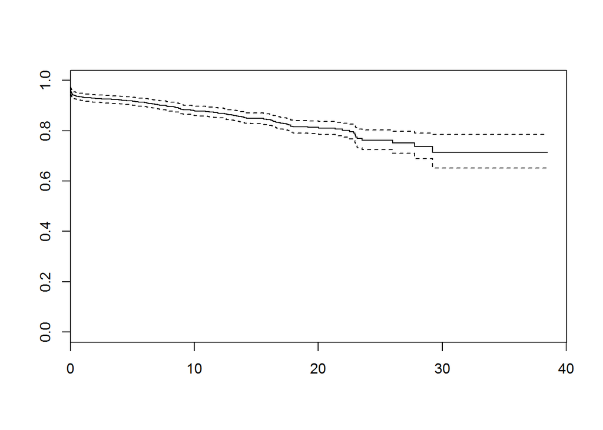

```r
c1[censor==0] <- c2[censor==0]
av_su <- Surv(time=round(c1, 4), event=censor)
plot(survfit(av_su~1))
```